# 上級マクロ経済学II

第3回 内生的成長

Author

荻巣嘉高

## ソローモデルの定常状態 vs データ

**Note理論的予測**

- $g_y = 0$
- $g_Y = n$

それなりにフィットしているように見えるが…

- ばらつきが大きい．
- 平均的にはやや上振れ．

成長をもたらす他のメカニズムが存在？

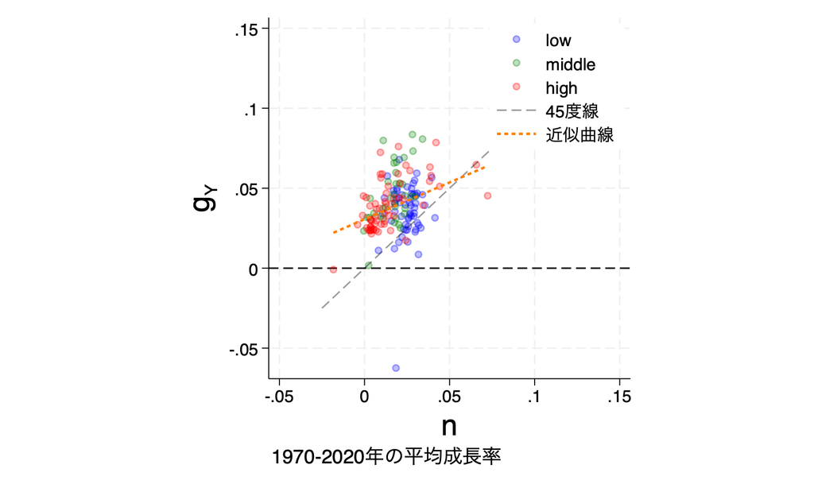

# 1 技術進歩を伴うソローモデル

## 技術進歩

- 経済に**外生的**技術進歩があるとする．
  - $A_{t+1} = (1+x) A$
  - $x$：技術進歩率

このとき，生産関数は
$$F(K_t, L_t; A_t) = K_t^{\alpha} (A_t L_{t})^{1-\alpha}$$

と表せる．

- $A_t L_t$は**効率労働**と呼ばれる．
- このような効率労働を使うモデルでは，「労働1単位当たり」*ではなく*，「効率労働1単位当たり」で基準化を行う．
  - $\hat{k}_t \equiv K_t / (A_t L_t)$
  - $\hat{y}_t \equiv Y_t / (A_t L_t)$

## ソローモデルと外生的技術進歩

生産関数の変化に伴い，ソローモデルのシステムは次のようになる．
$$\begin{aligned}
F(K_t, L_t; A_t) &= K_t^{\alpha} (A_t L_{t})^{1-\alpha} \\
K_{t+1} &= s F(K_t, L_t; A_t) - \delta K_t + K_t
\end{aligned}$$

- 効率労働（1単位）当たり資本$\hat{k}_t$について，$\Delta \hat{k}_{t+1} - \hat{k}_t = 0$で定常状態が与えられる．

## 成長の源泉

- 人口成長：$n$
- 技術進歩：$x$

一人当たりの所得の成長は達成される？

- 技術進歩が決定的に重要
- 技術水準$A$は何によって成長？
  - 現状は$x$は外生的．

# 2 内生的成長モデル

## 自律的に経済成長するモデル

- AKモデル (Romer, 1986)
- 教育と生産性のモデル（Lucas, 1988; Uzawa, 1965）
- R&D (Romer, 1990; Grossman and Helpman, 1991)

その他多数

**Note内生的成長モデル**

- 定常状態における経済成長率が外性的な技術進歩率以外の要因で説明される．
- モデル内部パラメータ（e.g., 貯蓄率）の変化によって成長率が変化する．

1つのキーワード：

- 資本の限界生産性の逓減

## AKモデル（setup）

生産関数が次の通りだとする．

$$Y_t = A K_t$$

家計の貯蓄率が$s$で一定なら，資本蓄積は次の通り（ソローモデルと同様）．
$$K_{t+1} = s Y_t + K_t - \delta K_t$$

## AKモデル（成長率）

このとき，
$$y_t = A k_t$$
$$k_{t+1} = s A k_t + (1-\delta) k_t$$
であり，
$$g_k = s A - \delta$$
なので，
$$g_y = g_k = s A - \delta$$

勝手に成長する．

## 解の概念

定常状態はどう定義する？

- 成長率ゼロが出てこない．
- 経済的に矛盾がない**何かが一定**の状態として定義．

**Note均斉成長（balanced growth）**

全ての時変変数の**成長率が一定**となる状態．

- 均斉成長にある時に経済変数がたどる経路のことを均斉成長経路（balanced growth path）とかいう．

AKモデルの定常状態は均斉成長$g_y = g_k = s A - \delta$で特徴付けられる．

- 勝手に成長するAKモデルvs勝手に成長しないソローモデル
  - 違いは？

## 全要素生産性の謎

- 経済成長率に対して$s$および全要素生産性$A$が決定的に重要

どう測る？

- **成長会計**
  - ソロー残差として計測

## スタート：コブ・ダグラス生産関

経済が次のような生産関数を持つと仮定．
$$Y_t = A_t K_t^{\alpha} L _t^{1-\alpha}$$

- 観測的事実と矛盾しない．
  - 安定的な労働分配率と資本分配率（$\alpha$）

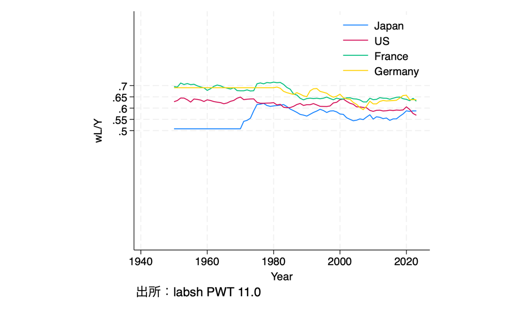

## 成長会計

コブ・ダグラス生産関数を前提にすれば成長率として次のように分解できる．
$$\frac{\Delta Y_t }{Y_t}= \frac{\Delta A_t }{A_t} + \alpha \frac{\Delta K_t }{K_t} + (1-\alpha) \frac{\Delta L_t }{L_t}$$

**Note成長会計**

GDP成長率をTFP，資本ストック，労働それぞれの成長率によって分解する手法．

## 成長要因の分解

- 推計されているもの：$\frac{\Delta Y_t }{Y_t},\frac{\Delta K_t }{K_t},\frac{\Delta L_t }{L_t}$
  - $\alpha$：資本分配率（約1/3）

ここから$\frac{\Delta A_t }{A_t}$を逆算．
$$\frac{\Delta A_t }{A_t} = \frac{\Delta Y_t }{Y_t} - \alpha \frac{\Delta K_t }{K_t} - (1-\alpha) \frac{\Delta L_t }{L_t}$$

- このときのTFP成長率はソロー残差とか言われる．
- この場合，$A$には資本の変化と労働の変化で説明できないもの全てが含まれていることに注意．
  - 純粋な”技術進歩”ではない．
  - e.g., 法，社会体制，金融システム，カルチャー，宗教，その他もろもろも含む．

## TFPのダイナミクス

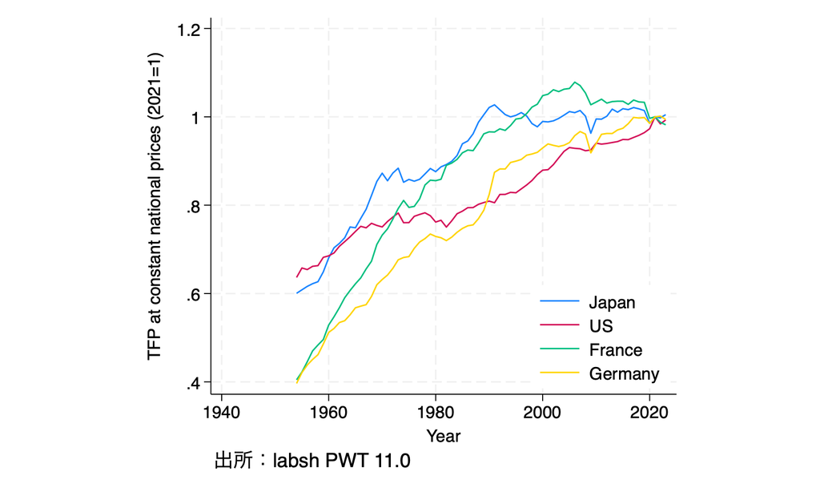

## 成長の源泉はなにか

- 技術開発（R&D）
- 教育（人的資本）
- 公共政策

## 技術開発

- Research & Development (R&D) 投資額の成長率との相関．
  - 固定効果モデルの係数(SE) = $0.03 (0.03)$

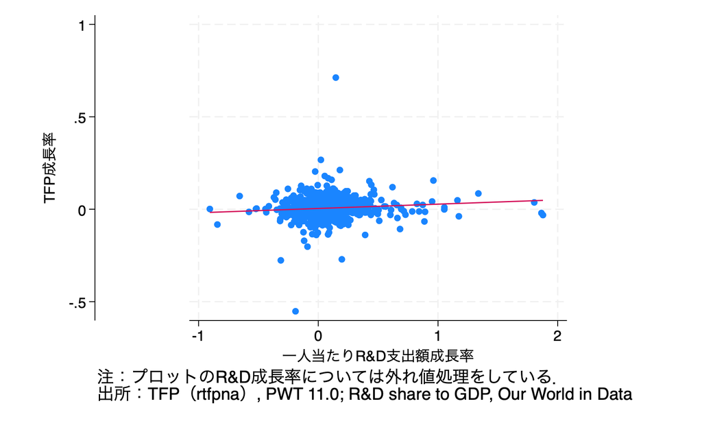

## 人的資本

- 人的資本インデックス
  - PWTでは，平均教育年数と教育の収益率から算出される．
  - 固定効果モデルの係数(SE) = $-0.00(0.005)$

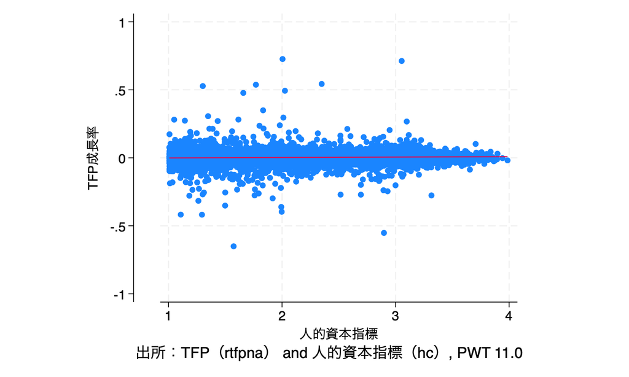

- 政府支出対GDP比率
  - 固定効果モデルの係数(SE) = $-0.032(0.014)$

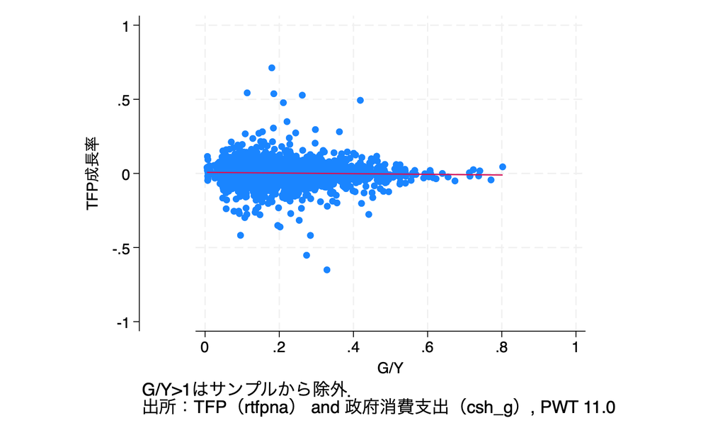

## ポイント

- 理論的なパス$\neq$実証的な観測
  - 理論が果たす役割と実証が果たす役割を理解する．
- マクロデータから実証的な含意を出すことの難しさ．
  - 種々のノイズ．
  - 数多の経路と交絡．
  - 近年のマイクロデータの普及 & 因果推論の枠組みが果たす役割は大きい．

## TFPから内生成長へ

- TFPの中身が特殊な形状をしていると考えれば，内生成長は達成されうる．
  - 理論的な研究は数多ある．

TFPに何が寄与しうるかを理論的な枠組みで整理

- 今回はRomer (1986)タイプを紹介．

## Learning by Doing

生産関数が次のように与えられれている．
$$Y_t = A_t K_t^{\alpha} L^{1-\alpha}$$

このときに，TFPである$A$が，次のようになっていると仮定．
$$A_t = B \left( \frac{K_t}{L_t} \right)^{1-\alpha}$$
ただし，$B>0$は定数．

- 一人当たり資本が増えるほど，各人が資本の取り扱いに慣れやすくなる．
  - 一人当たりの資本蓄積が外部性を持つと言い換えてもよい．

## マクロでの生産関数

$$Y_t = B K_t$$
に帰着．

最も基本的なAKモデルに帰着．

- 資本の限界生産力逓減を壊すことがキーになっている．